# Coffee

# Description

```r
skimr::skim(coffee)
```

[output not shown]

Observe the results of the `skimr` in combination with the dictionary given on the Tidy Tuesday website. The unit of observation is what? I think it’s one type of coffee, or one brand of coffee. Is there a difference? Do most farms produce only one type of coffee? In any case, they can be rated, and that’s what’s been done. To get an ID variable, you would use either farm_name, ico_number, or company. It’s unclear. Let’s refer back to the `skimr` results. There are 1,339 observations, but none of the variables has 1,339 unique observations, so there is no clear ID variable. In Stata I would use the `isid` function, but I don’t have that option here.

So, presumably, some combination of variables will yield a proper ID. ICO number has 847 unique values, and farm name has 571. Producer has 691. Grading date and expiration have almost the same number of unique values as farm name, so that’s a good lead.

According to the source, “these data contain reviews of 1,312 arabica and 28 robusta coffee beans from the Coffee Quality Institute’s trained reviewers.” And the farm metadata consists of the following variables:

- Owner
- Country of origin
- Farm name
- Lot number
- Mill
- Company
- Altitude
- Region

So, some combination of those will maybe yield an ID.

Looking through the data by hand, I do not see any likelihood of an ID variable unless I arbitrarily create one. The first two observations are identical in nearly everything, the only differences being variety, the scores, and category two defects. Otherwise, the columns are exactly identical. This leads me to believe that the coffe was either (a) a standard and a variety, or (b) the same coffee tested twice in the same day by two different testers. I hope the second is the case, because the first would make my life a little more difficult.

It’s a little annoying because the description says the data is on different beans. These beans are difficult to distinguish if you ask me.

Okay, let’s define a new unit of observation, then. The old unit (the current one) is the unit of review, which can include multiple reviews of the same coffee, even the same batch on the same day. Instead, I can summarize to the company, region (interesting perhaps), mill, farm, or owner. I think I will look briefly at which regions score the highest in which categories.

# Which regions score highest?

In wine, year and location matter, so in this section I will summarize by region and harvest_year. The possible criteria are:

- aroma
- flavor
- aftertaste
- acidity
- body
- balance
- uniformity
- clean cup (`clean_cup`)
- sweetness
- cupper points (`cupper_points`)
- moisture
- total cup points (`total_cup_points`)

Except where mentioned, the name mentioned above is the same as the variable name in the dataset.

# Back to cleaning

The batch year variable looks very bad. Lots to clean there. 47 unique values.

```r
coffee %>%
  tabyl(harvest_year)
```

```
             harvest_year   n     percent valid_percent
               08/09 crop   2 0.001493652  0.0015479876
                  1t/2011   1 0.000746826  0.0007739938
                  1T/2011   1 0.000746826  0.0007739938
                2009-2010   3 0.002240478  0.0023219814
              2009 - 2010   1 0.000746826  0.0007739938
              2009 / 2010   1 0.000746826  0.0007739938
                2009/2010  12 0.008961912  0.0092879257
                     2010  10 0.007468260  0.0077399381
                2010-2011   6 0.004480956  0.0046439628
                     2011  26 0.019417476  0.0201238390
                2011/2012   2 0.001493652  0.0015479876
                     2012 354 0.264376400  0.2739938080
                     2013 181 0.135175504  0.1400928793
                2013/2014  29 0.021657954  0.0224458204
                     2014 233 0.174010456  0.1803405573
                2014/2015  19 0.014189694  0.0147058824
                     2015 129 0.096340553  0.0998452012
                2015/2016  28 0.020911128  0.0216718266
                     2016 124 0.092606423  0.0959752322
              2016 / 2017   6 0.004480956  0.0046439628
                2016/2017   1 0.000746826  0.0007739938
                     2017  70 0.052277819  0.0541795666
              2017 / 2018  19 0.014189694  0.0147058824
                     2018   1 0.000746826  0.0007739938
             23 July 2010   1 0.000746826  0.0007739938
                  3T/2011   1 0.000746826  0.0007739938
                  47/2010   1 0.000746826  0.0007739938
                    4T/10   4 0.002987304  0.0030959752
                  4t/2010   1 0.000746826  0.0007739938
                  4T/2010   3 0.002240478  0.0023219814
                  4t/2011   1 0.000746826  0.0007739938
                  4T72010   1 0.000746826  0.0007739938
            Abril - Julio   2 0.001493652  0.0015479876
      Abril - Julio /2011   1 0.000746826  0.0007739938
       August to December   1 0.000746826  0.0007739938
 December 2009-March 2010   1 0.000746826  0.0007739938
                Fall 2009   1 0.000746826  0.0007739938
             January 2011   2 0.001493652  0.0015479876
    January Through April   1 0.000746826  0.0007739938
               March 2010   3 0.002240478  0.0023219814
               May-August   1 0.000746826  0.0007739938
             Mayo a Julio   3 0.002240478  0.0023219814
                      mmm   1 0.000746826  0.0007739938
   Sept 2009 - April 2010   1 0.000746826  0.0007739938
 Spring 2011 in Colombia.   1 0.000746826  0.0007739938
                     TEST   1 0.000746826  0.0007739938
                     <NA>  47 0.035100822            NA
```

Some forms jump out:

- #t/yyyy (‘t’ may or may not be capitalized)
- month yyyy - month yyyy (some variations with spacing)
- yyyy / yyyy
- yyyy

These ones are definitely salvagable. The others occasionally are, and sometimes there is no hope because there is no year listed. Nearly all years are formatted with one of the last two options, so I will aim primarily for those.

[output not shown]

[output cut: 990 more lines]

So, that should take care of that I suppose.

# Back to summaries

Okay, back to the summary of before.

```r
coffee_region <- coffee %>%
  group_by(year, region) %>%
  summarize(
    total_cup_points = mean(total_cup_points, na.rm = TRUE),
    cupper_points = mean(cupper_points, na.rm = TRUE),
    clean_cup = mean(clean_cup, na.rm = TRUE),
    aroma = mean(aroma, na.rm = TRUE),
    flavor = mean(flavor, na.rm = TRUE),
    aftertaste = mean(aftertaste, na.rm = TRUE),
    acidity = mean(acidity, na.rm = TRUE),
    body = mean(body, na.rm = TRUE),
    balance = mean(balance, na.rm = TRUE),
    sweetness = mean(sweetness, na.rm = TRUE),
    moisture = mean(moisture, na.rm = TRUE)
  )
```

```
Factor `year` contains implicit NA, consider using `forcats::fct_explicit_na`
```

I imagine a line graph would represent this okay. Here’s a line graph of every quality over time, each line representing a region and each facet a quality.

```
Factor `year` contains implicit NA, consider using `forcats::fct_explicit_na`Factor `year` contains implicit NA, consider using `forcats::fct_explicit_na`Factor `year` contains implicit NA, consider using `forcats::fct_explicit_na`
```

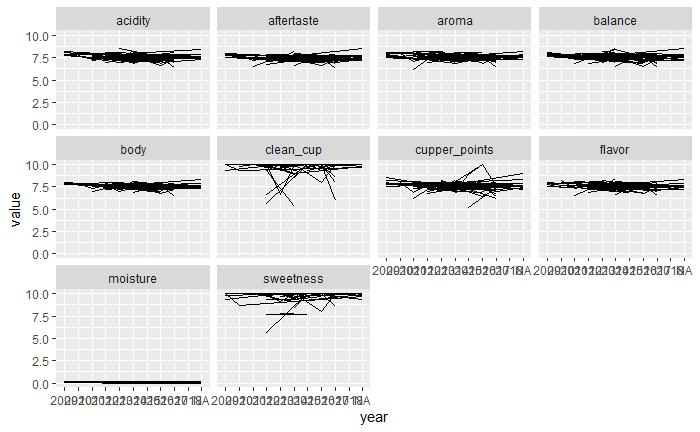

```r
coffee_region %>%
  pivot_longer(cols = cupper_points:moisture,
               names_to = "quality",
               values_to = "value") %>%
  ggplot() +
  geom_line(aes(x = year, y = value, group = region)) +
  facet_wrap(vars(quality))
```

Not much to look at here. The greatest variation occurs in clean cup, sweetness, and cupper points, although those might be attributable only to population. Clean cup and sweetness in particular look light. Moisture is on another scale. I would expect the most variation to occur in taste (acidity, aroma, flavor, sweetness), but this is an uneducated guess. I would have to do some reading to properly expect something.

Let’s do the same analysis with country, although it might not mean as much.

```
Factor `year` contains implicit NA, consider using `forcats::fct_explicit_na`Factor `year` contains implicit NA, consider using `forcats::fct_explicit_na`Factor `year` contains implicit NA, consider using `forcats::fct_explicit_na`
```

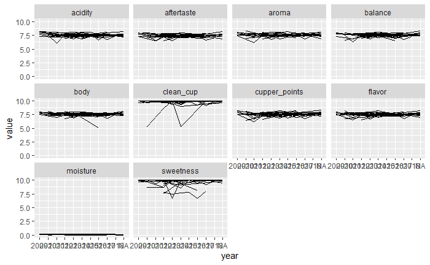

```r
coffee_country %>%
  pivot_longer(cols = cupper_points:moisture,
               names_to = "quality",
               values_to = "value") %>%
  ggplot() +
  geom_line(aes(x = year, y = value, group = country_of_origin)) +
  facet_wrap(vars(quality))
```

Again, we see a pattern of high variation in clean cup (what is this?) and sweetness. Even with more observations, it’s unlikely sweetness would iron itself out much more. Let’s look closer.

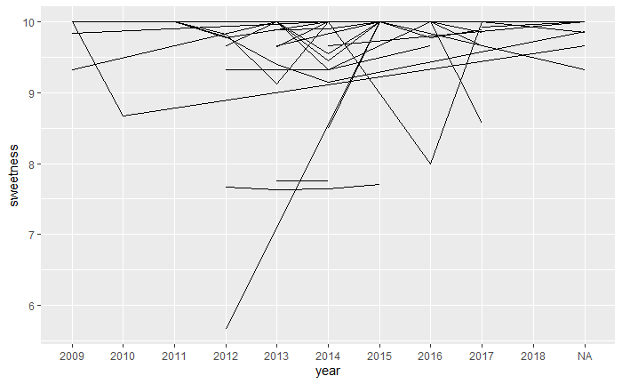

| year | region | total_cup_points | cupper_points | clean_cup | aroma | flavor | aftertaste | acidity | body | balance | sweetness | moisture |
| --- | --- | --- | --- | --- | --- | --- | --- | --- | --- | --- | --- | --- |
| 2012 | nuevo oriente | 72.83 | 7.335 | 5.665 | 7.75 | 7.335 | 7.25 | 8 | 7.58 | 7.25 | 5.665 | 0.1 |

So, Nuevo Oriente had a bad year in 2012. They turned it around to an almost perfect 10 in 2015, though. Let’s graph Nuevo Oriente (which, by the way, is in central Colombia).

```
Factor `year` contains implicit NA, consider using `forcats::fct_explicit_na`Factor `year` contains implicit NA, consider using `forcats::fct_explicit_na`Factor `year` contains implicit NA, consider using `forcats::fct_explicit_na`
```

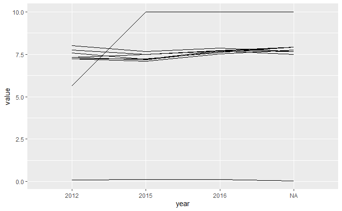

```r
coffee_region %>%
  filter(region == "nuevo oriente") %>%
  pivot_longer(cols = cupper_points:moisture,
               names_to = "quality",
               values_to = "value") %>%
  ggplot() +
  geom_line(aes(x = year, y = value, group = quality))
```

There’s a lot to explore with this geographic interpretation. You could look at latitudes and longitudes and the sweetness and whether there’s an association with, say, southernness. You could also connect that to weather records to figure out whether weather (say temperature) has an impact on the taste of the coffee. This would involve some serious web scraping and data manipulation that would set me back at least a week if not more. And that’s if I figure out a way to get the coordinates of every single (or most) farm, no small task I would guess.